# Homework1

Orlando Harrisson, David Istvan

1 juillet 2019

# Section 3: Group Members

David Istvan:

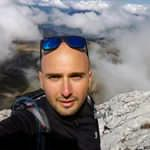

David in the mountains

My favourite hobby is snowboarding, because it gives me the feeling that I am free:

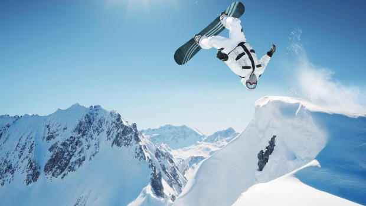

(No that’s not me)

An interesting fact about me is that I don’t like to sleep. I could get so many things done instead!

My favourite quote:

> Imagination is more important than knowledge A. Einstein

Orlando Harrisson:

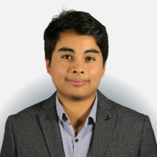

Orlando having a good time

I like to swim in the lake on summer and skiing on the mountains in winter. Yet, my favorite season is autumn because I like to see the forests with yellow leaves and eat marrons chauds. My favorite quote is:

> Don't do unto others what you don't want done unto you. - Confucius

# Section 2: Introduction

## Section 4 answer:

In our opinion the values will not be exactly 0 and 1. Our sample has values with mean of zero and variance of 1 therefore when the 100 values are randomly extracted from this distribution it makes sense that the simulation will not have exact values.